# **Insper - Ciência dos Dados**

## **Projeto 3:**

Membros:

- Antonio Vieira Fuziy
- Willian Kenzo
- Ramon Menegatto
- André Rocco

### Pergunta e Contexto:

- A base de dados escolhida pelo grupo foi retirada do site Kaggle, esse DataFrame é fictício e foi criado por cientistas de dados da IBM com a finalidade de gerar um desafio para que as pessoas tentassem analisar atributos e o desempenho de funcionários da IBM HR Analytics. Assim, a partir desses dados o desafio do nosso grupo seria analisar não só o desempenho e os atributos dos funcionários da IBM, mas também tentar prever a demissão ou saída de um funcionário com auxílio de machine learning.

**Link para a base de dados:** [IBM HR Analytics Employee Attrition & Performance](https://www.kaggle.com/pavansubhasht/ibm-hr-analytics-attrition-dataset)

**DataFrame principal do projeto:** `IBM`

- Utilizando a base de dados da empresa, formulamos a seguinte pergunta:

  Qual seriam os parâmetros e as variáveis que influenciam na saída de funcionários da empresa, e a partir dessas variáveis, quais seriam os perfis das pessoas que podem acabar saindo por opinião própria ou sendo demitidas da empresa?

**Importando Bibliotecas:**

```python
import pandas as pd
import numpy as np
import matplotlib.pyplot as plt
import statsmodels.api as sm
import seaborn as sns
import plotly.express as px
import plotly.offline as py
import plotly.graph_objs as go
import plotly.tools as tls
import plotly.figure_factory as ff
from sklearn.ensemble import RandomForestRegressor
from sklearn.preprocessing import StandardScaler
from sklearn.model_selection import train_test_split
from imblearn.over_sampling import SMOTE
from sklearn.ensemble import RandomForestClassifier, GradientBoostingClassifier
from sklearn.metrics import accuracy_score, log_loss
from xgboost import XGBClassifier
from sklearn import datasets, linear_model, metrics
from sklearn.svm import SVC
from sklearn.metrics import classification_report, confusion_matrix
from sklearn.ensemble import AdaBoostClassifier
from sklearn.linear_model import SGDClassifier
```

```python
#Importando Excel:
IBM_semfiltro = pd.read_csv('IBM.csv')

#Filtrando colunas do DataFrame:
IBM = IBM_semfiltro.drop(columns=['EmployeeCount','StandardHours','Over18','DailyRate'])

IBM.head()
```

|  | Age | Attrition | BusinessTravel | Department | DistanceFromHome | Education | EducationField | EmployeeNumber | EnvironmentSatisfaction | Gender | ... | PerformanceRating | RelationshipSatisfaction | StockOptionLevel | TotalWorkingYears | TrainingTimesLastYear | WorkLifeBalance | YearsAtCompany | YearsInCurrentRole | YearsSinceLastPromotion | YearsWithCurrManager |
| --- | --- | --- | --- | --- | --- | --- | --- | --- | --- | --- | --- | --- | --- | --- | --- | --- | --- | --- | --- | --- | --- |
| 0 | 41 | Yes | Travel_Rarely | Sales | 1 | 2 | Life Sciences | 1 | 2 | Female | ... | 3 | 1 | 0 | 8 | 0 | 1 | 6 | 4 | 0 | 5 |
| 1 | 49 | No | Travel_Frequently | Research & Development | 8 | 1 | Life Sciences | 2 | 3 | Male | ... | 4 | 4 | 1 | 10 | 3 | 3 | 10 | 7 | 1 | 7 |
| 2 | 37 | Yes | Travel_Rarely | Research & Development | 2 | 2 | Other | 4 | 4 | Male | ... | 3 | 2 | 0 | 7 | 3 | 3 | 0 | 0 | 0 | 0 |
| 3 | 33 | No | Travel_Frequently | Research & Development | 3 | 4 | Life Sciences | 5 | 4 | Female | ... | 3 | 3 | 0 | 8 | 3 | 3 | 8 | 7 | 3 | 0 |
| 4 | 27 | No | Travel_Rarely | Research & Development | 2 | 1 | Medical | 7 | 1 | Male | ... | 3 | 4 | 1 | 6 | 3 | 3 | 2 | 2 | 2 | 2 |

5 rows × 31 columns

```python
#Criando DataFrame que substitui a coluna Attrition = 'Yes' por 1:
IBM.loc[IBM['Attrition'] == 'Yes', 'Attrition'] = 1

#Criando DataFrame que substitui a coluna Attrition = 'No' por 0:
IBM.loc[IBM['Attrition'] == 'No', 'Attrition'] = 0
```

- **Gráfico de Correlação das variáveis do DataFrame:**

**Legenda:**

- **Vermelho: Correlação Positiva**
- **Azul: Correlação Negativa**

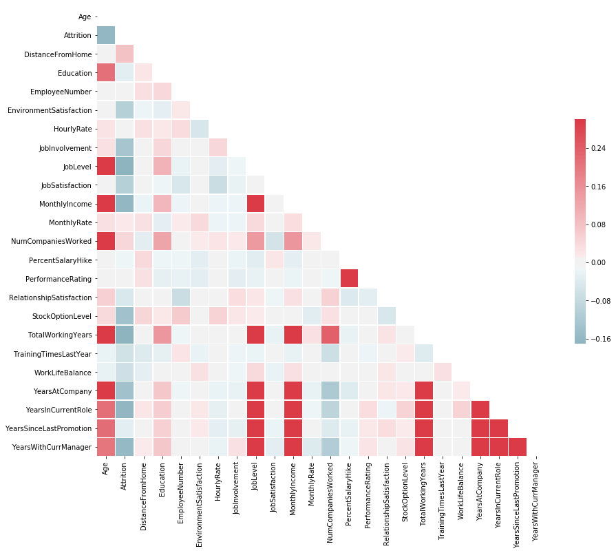

```python
#Criando correlação das variáveis:
corr=IBM.corr()

mask = np.zeros_like(corr, dtype=np.bool)
mask[np.triu_indices_from(mask)] = True

#Setando a figura:
f, ax = plt.subplots(figsize=(15, 12))

#Gerando as cores do as corelações:
cmap = sns.diverging_palette(220, 10, as_cmap=True)

#Printando Matriz de correlação:
sns.heatmap(corr, mask=mask, cmap=cmap, vmax=.3, center=0,
            square=True, linewidths=.5, cbar_kws={"shrink": .5});
```

- Nesse gráfico feito por heatmap conseguimos detectar que diversas de nossas variáveis possuem correlações entre si, mesmo se consideradas baixas, como idade e anos na empresa, ou salário mensal e idade, o que já era esperado
- **Gráfico de correlação das variáveis da empresa plotado de forma diferente para ter uma visualização diferente do gráfico acima:**

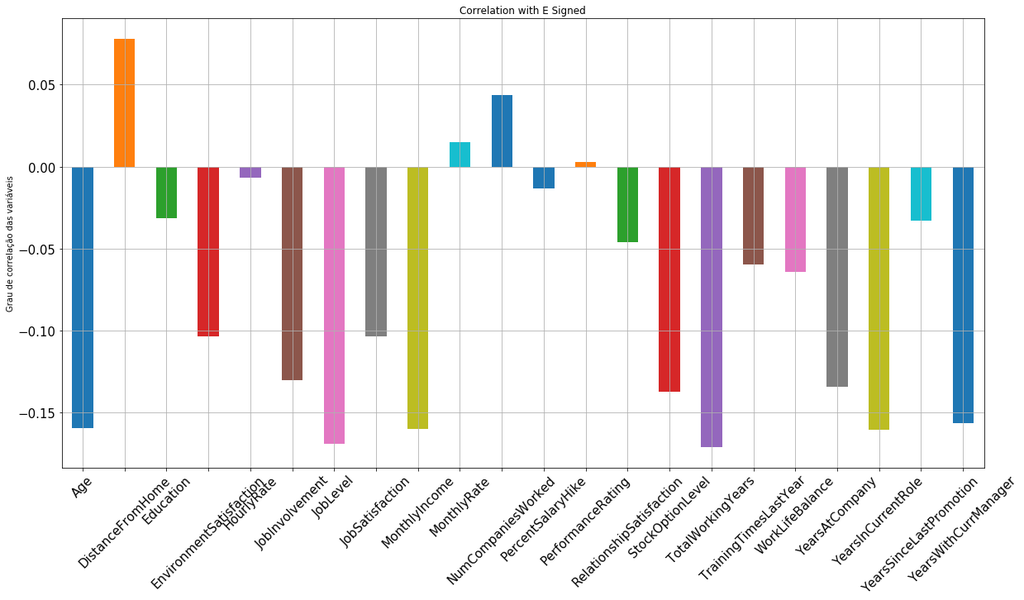

```python
continuous_columns = ['Age','DistanceFromHome', 'Education', 'EnvironmentSatisfaction','HourlyRate','JobInvolvement','JobLevel','JobSatisfaction', 'MonthlyIncome', 'MonthlyRate', 'NumCompaniesWorked','PercentSalaryHike',  'PerformanceRating', 'RelationshipSatisfaction','StockOptionLevel', 'TotalWorkingYears', 'TrainingTimesLastYear','WorkLifeBalance', 'YearsAtCompany', 'YearsInCurrentRole', 'YearsSinceLastPromotion','YearsWithCurrManager']
b=IBM[continuous_columns]

a=b.corrwith(IBM['Attrition']).plot.bar(
        figsize = (20,10), title = "Correlation with E Signed", fontsize = 15,
        rot = 45, grid = True)
plt.ylabel('Grau de correlação das variáveis');
```

- Pode-se notar que a maioria de nossas variáveis tem correlação negativa com a principal(Attrition) o que nos leva a deduzir que quando uma aumenta, a outra diminui, mas o mais importante que pode ser retirado do gráfico feito é que a maioria de nossas variáveis não tem um grande impacto, já que o grau de correlação vai de 1 a -1 e no gráfico acima o máximo que temos é de 0.18

```python
#Printando DataFrame para visualização dos parâmetros.
IBM.iloc[:,0:20].head()
```

|  | Age | Attrition | BusinessTravel | Department | DistanceFromHome | Education | EducationField | EmployeeNumber | EnvironmentSatisfaction | Gender | HourlyRate | JobInvolvement | JobLevel | JobRole | JobSatisfaction | MaritalStatus | MonthlyIncome | MonthlyRate | NumCompaniesWorked | OverTime |
| --- | --- | --- | --- | --- | --- | --- | --- | --- | --- | --- | --- | --- | --- | --- | --- | --- | --- | --- | --- | --- |
| 0 | 41 | 1 | Travel_Rarely | Sales | 1 | 2 | Life Sciences | 1 | 2 | Female | 94 | 3 | 2 | Sales Executive | 4 | Single | 5993 | 19479 | 8 | Yes |
| 1 | 49 | 0 | Travel_Frequently | Research & Development | 8 | 1 | Life Sciences | 2 | 3 | Male | 61 | 2 | 2 | Research Scientist | 2 | Married | 5130 | 24907 | 1 | No |
| 2 | 37 | 1 | Travel_Rarely | Research & Development | 2 | 2 | Other | 4 | 4 | Male | 92 | 2 | 1 | Laboratory Technician | 3 | Single | 2090 | 2396 | 6 | Yes |
| 3 | 33 | 0 | Travel_Frequently | Research & Development | 3 | 4 | Life Sciences | 5 | 4 | Female | 56 | 3 | 1 | Research Scientist | 3 | Married | 2909 | 23159 | 1 | Yes |
| 4 | 27 | 0 | Travel_Rarely | Research & Development | 2 | 1 | Medical | 7 | 1 | Male | 40 | 3 | 1 | Laboratory Technician | 2 | Married | 3468 | 16632 | 9 | No |

```python
#Printando DataFrame para visualização dos parâmetros.
IBM.iloc[:,20:35].head()
```

|  | PercentSalaryHike | PerformanceRating | RelationshipSatisfaction | StockOptionLevel | TotalWorkingYears | TrainingTimesLastYear | WorkLifeBalance | YearsAtCompany | YearsInCurrentRole | YearsSinceLastPromotion | YearsWithCurrManager |
| --- | --- | --- | --- | --- | --- | --- | --- | --- | --- | --- | --- |
| 0 | 11 | 3 | 1 | 0 | 8 | 0 | 1 | 6 | 4 | 0 | 5 |
| 1 | 23 | 4 | 4 | 1 | 10 | 3 | 3 | 10 | 7 | 1 | 7 |
| 2 | 15 | 3 | 2 | 0 | 7 | 3 | 3 | 0 | 0 | 0 | 0 |
| 3 | 11 | 3 | 3 | 0 | 8 | 3 | 3 | 8 | 7 | 3 | 0 |
| 4 | 12 | 3 | 4 | 1 | 6 | 3 | 3 | 2 | 2 | 2 | 2 |

```python
#DataFrame das pessoas com Sem Atrito com a empresa:
NoAttrition = IBM.loc[(IBM['Attrition']==0)]

#DataFrame das pessoas com Atrito com a empresa:
Attrition = IBM.loc[(IBM['Attrition']==1)]
```

```python
IBM.iloc[:,0:20].head()
```

|  | Age | Attrition | BusinessTravel | Department | DistanceFromHome | Education | EducationField | EmployeeNumber | EnvironmentSatisfaction | Gender | HourlyRate | JobInvolvement | JobLevel | JobRole | JobSatisfaction | MaritalStatus | MonthlyIncome | MonthlyRate | NumCompaniesWorked | OverTime |
| --- | --- | --- | --- | --- | --- | --- | --- | --- | --- | --- | --- | --- | --- | --- | --- | --- | --- | --- | --- | --- |
| 0 | 41 | 1 | Travel_Rarely | Sales | 1 | 2 | Life Sciences | 1 | 2 | Female | 94 | 3 | 2 | Sales Executive | 4 | Single | 5993 | 19479 | 8 | Yes |
| 1 | 49 | 0 | Travel_Frequently | Research & Development | 8 | 1 | Life Sciences | 2 | 3 | Male | 61 | 2 | 2 | Research Scientist | 2 | Married | 5130 | 24907 | 1 | No |
| 2 | 37 | 1 | Travel_Rarely | Research & Development | 2 | 2 | Other | 4 | 4 | Male | 92 | 2 | 1 | Laboratory Technician | 3 | Single | 2090 | 2396 | 6 | Yes |
| 3 | 33 | 0 | Travel_Frequently | Research & Development | 3 | 4 | Life Sciences | 5 | 4 | Female | 56 | 3 | 1 | Research Scientist | 3 | Married | 2909 | 23159 | 1 | Yes |
| 4 | 27 | 0 | Travel_Rarely | Research & Development | 2 | 1 | Medical | 7 | 1 | Male | 40 | 3 | 1 | Laboratory Technician | 2 | Married | 3468 | 16632 | 9 | No |

- **Criando função para plotar os gráficos de pizza para comparar as variáveis qualitativas do DataFrame:**

```python
#foi usado um def encontrado na internet como referencia, erro no codigo legenda errada
def plot(va) :

    colors = ['darkblue', 'darkorange', 'darkgreen', 'darkred', 'lightgrey', 'orange', 'white', 'lightpink']
    trace1 = go.Pie(values  = Attrition[va].value_counts().values.tolist(),
                    labels  = Attrition[va].value_counts().keys().tolist(),
                    textfont=dict(size=15), opacity = 0.8,
                    hoverinfo = "label+percent+name",
                    domain  = dict(x = [0,.48]),
                    name    = "attrition employes",
                    marker  = dict(colors = colors, line = dict(width = 1.5)))
    trace2 = go.Pie(values  = NoAttrition[va].value_counts().values.tolist(),
                    labels  = NoAttrition[va].value_counts().keys().tolist(),
                    textfont=dict(size=15), opacity = 0.8,
                    hoverinfo = "label+percent+name",
                    marker  = dict(colors = colors, line = dict(width = 1.5)),
                    domain  = dict(x = [.52,1]),
                    name    = "Non attrition employes" )

    layout = go.Layout(dict(title = va + " distribution in employes attrition ",
                            annotations = [dict(text = "Yes_attrition",
                                                font = dict(size = 13),
                                                showarrow = False,
                                                x = .22, y = -0.1),
                                            dict(text = "No_attrition",
                                                font = dict(size = 13),
                                                showarrow = False,
                                                x = .8,y = -.1)]))


    fig  = go.Figure(data = [trace1,trace2],layout = layout)
    py.iplot(fig)
```

#### **Gráfico que mostra a quantidade de pessoas com attrition e sem da empresa**

**Estamos utilizando 1 como sendo que teve atrito e 0 como não**

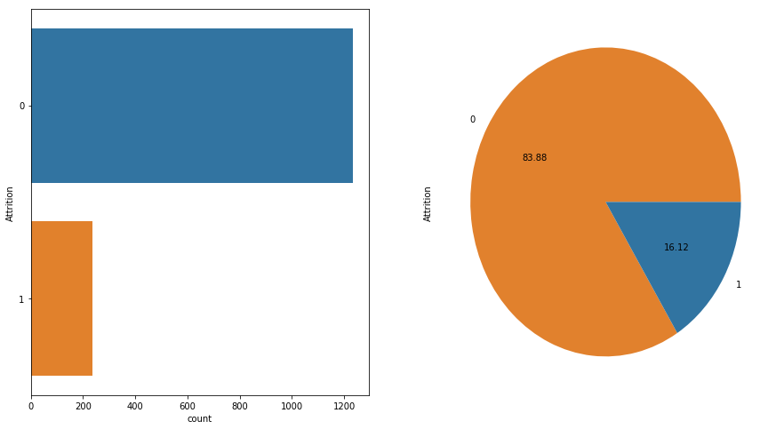

```python
attri=IBM.Attrition.value_counts()
plt.figure(figsize=(15,8))
plt.subplot(121)
x = sns.countplot(y="Attrition",  data=IBM)
plt.subplot(122)
attri.plot(kind='pie', colors=('#E1812D','#3174A1'), autopct="%.2f", legend=False)
```

- **Plotando os gráficos de pessoas que tem atrito e não tem atrito com a empresa, relacionando-as a satisfação dos funcionários com o trabalho:**

Legenda:

JobSatisfaction:

- **1: Low**
- **2: Medium**
- **3: High**
- **4: Very High**

```python
plot("JobSatisfaction")
```

[interactive chart not shown]

- Os gráficos de pizza acima mostram que as pessoas que não estão satisfeitas com o trabalho tendem a sair mais, pois estas compõem 19,6% de todas as pessoas, e para que esta variável pudesse ser considerado pouco relevante para a análise o valor dessa porcentagem deveria ser parecido, porém este subiu para 27,8%.
- **Plotando os gráficos de pessoas que tem atrito e não tem atrito com a empresa, relacionando-as com seu estado civil:**

```python
plot("MaritalStatus")
```

[interactive chart not shown]

- O gráfico de pizza acima mostra que a maior parte das pessoas que tem atrito com a empresa é solteiro, e a maior quantidade de pessoas que não tem atrito são casados, o que pode estar relacionado com que quando se está solteiro, as pessoas costumam a se arriscar mais.
- **Plotando os gráficos de pessoas que tem atrito e não tem atrito com a empresa, relacionando-as a Gênero dos funcinários:**

```python
plot("Gender")
```

[interactive chart not shown]

- Os gráficos acima nos mostram que das pessoas que saem 63,3% são do gênero masculino. Mesmo a quantidade de homens sendo maior que a quantidade de mulheres na empresa(60% de homens e 40%) a porcentagem de homens que saem em relação aos homens é maior que a de mulheres em relação a elas.
- **Plotando o gráfico de pessoas que tem atrito e não tem atrito com a empresa, relacionando-as ao Número de Companias que a pessoa trabalhou antes:**

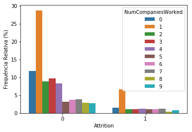

```python
sns.barplot(x='Attrition',y="Attrition",hue="NumCompaniesWorked", data=IBM, estimator=lambda x: len(x) / len(IBM) * 100);
plt.ylabel('Frequência Relativa (%)');
```

- O número de companhias que a pessoa já trabalhou não é um fator muito relevante para a saída ou permanência desse indivíduo na empresa.
- **Plotando o gráfico de pessoas que tem atrito e não tem atrito com a empresa, relacionando-as a Frequência que a pessoa viaja a trabalho:**

```python
plot("BusinessTravel")
```

[interactive chart not shown]

- Baseado nos gráficos pode-se concluir que em quantidade as pessoas que viajam raramente à negócios saem mais, isso ocorre pois dentro da população da empresa existem mais pessoas que viajam raramente do que o resto. Porém quando se fala em porcentagem dentro de seus grupos os indivíduos que viajam frequentemente saem mais.
- **Plotando o gráfico de pessoas que tem atrito e não tem atrito com a empresa, relacionando-as a Área de Formação dos funcionários:**

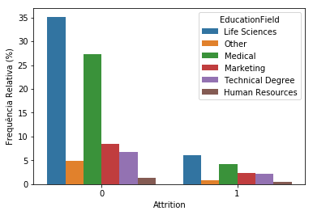

```python
sns.barplot(x='Attrition',y="Attrition",hue="EducationField", data=IBM, estimator=lambda x: len(x) / len(IBM) * 100);
plt.ylabel('Frequência Relativa (%)');
```

- **Plotando o gráfico de pessoas que tem atrito e não tem atrito com a empresa, relacionando-as a Área de Trabalho dos funcionários:**

```python
plot("JobRole")
```

[interactive chart not shown]

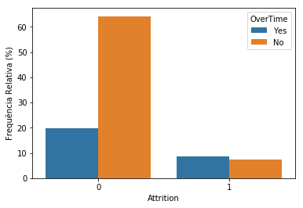

```python
sns.barplot(x='Attrition',y="Attrition",hue="OverTime", data=IBM, estimator=lambda x: len(x) / len(IBM) * 100);
plt.ylabel('Frequência Relativa (%)');
```

- Uma coisa interessante enquanto analisavamos nossas variáveis que não pensamos que seria assim, é que a maior quantidade das pessoas que não trabalham hora extra permanecem na empresa, sendo que o grupo acreditava que seria o contrário, otimo insight para a continuação do projeto
- **Plotando o gráfico de pessoas que tem atrito e não tem atrito com a empresa, relacionando-as com a perfomance do indivíduo:**

Legenda:

PerformanceRating:

- **1: Low**
- **2: Good**
- **3: Excellent**
- **4: Outstanding**

```python
plot("PerformanceRating")
```

[interactive chart not shown]

- O gráfico acima mostra que perfomance rating não é uma variável muito imporante para definir se o empregado terá ou não atrito com a empresa, , por isso não será considerado.
- **Plotando o gráfico de pessoas que tem atrito e não tem atrito com a empresa, relacionando-as com StockOptionLevel (a empresa fornece ao funcionário a opção de adquirir as ações da empresa a um valor pré-determinado passado um certo período de tempo) :**

[interactive chart not shown]

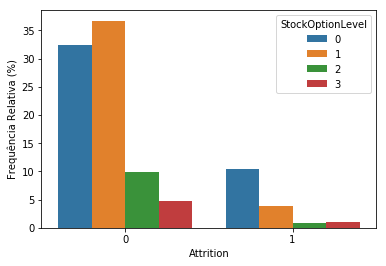

```python
sns.barplot(x='Attrition',y="Attrition",hue="StockOptionLevel", data=IBM, estimator=lambda x: len(x) / len(IBM) * 100);
plot('StockOptionLevel')
plt.ylabel('Frequência Relativa (%)');
```

**Legenda:**

WorkLifeBalance:

- **1: Bad**
- **2: Good**
- **3: Better**
- **4: Best**

```python
plot("WorkLifeBalance")
```

[interactive chart not shown]

- Pessoas que não conseguem balancear a sua rotina no trabalho com sua vida social, possuem uma maior chance de saírem. Isso pode ser explicado pois uma pessoa com um tempo mal organizado normalmente apresenta um rendimento abaixo do esperado. Já as pessoas que balanceiam melhor sua rotina, conseguem administrar melhor seu tempo e por isso não apresentam tanto atrito com a empresa.
- **Histograma que mostra os anos na mesma posição de trabalho:**

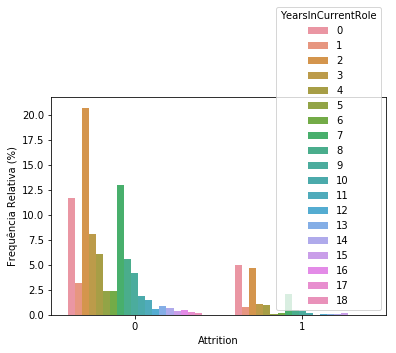

```python
sns.barplot(x='Attrition',y="Attrition",hue="YearsInCurrentRole", data=IBM, estimator=lambda x: len(x) / len(IBM) * 100);
plt.ylabel('Frequência Relativa (%)');
```

- Os gráficos nos permitem concluir que pessoas que acabaram de começar em sua posição possuem mais chances de entrar em atrito com a empresa do que pessoas em suas posições a mais tempo.
- **Histograma que motra a frequência relativa dos funcionários desde a última promoção:**

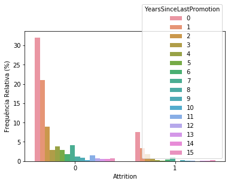

```python
sns.barplot(x='Attrition',y="Attrition",hue="YearsSinceLastPromotion", data=IBM, estimator=lambda x: len(x) / len(IBM) * 100);
plt.ylabel('Frequência Relativa (%)');
```

- **Histograma com a frequência relativa dos funcionários com seu gerente atual**

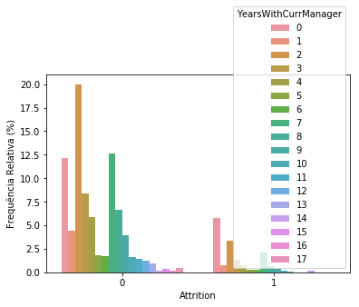

```python
sns.barplot(x='Attrition',y="Attrition",hue="YearsWithCurrManager", data=IBM, estimator=lambda x: len(x) / len(IBM) * 100);
plt.ylabel('Frequência Relativa (%)');
```

- **Gráfico com a frequência relativa dos funcionários na empresa:**

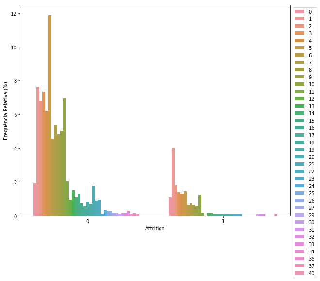

```python
plt.figure(figsize=(10,8))
sns.barplot(x='Attrition',y="Attrition",hue="YearsAtCompany", data=IBM, estimator=lambda x: len(x) / len(IBM) * 100);
plt.legend(loc='best',bbox_to_anchor=(1,1))
plt.ylabel('Frequência Relativa (%)');
```

- ### Gráficos de violino para a comparação entre variável quantitativa x qualitativa:

Gráficos de violino são semelhantes a boxplot, mas com a adição de um gráfico de densidade de kernel adicionado a cada lado

- **Gráfico comparando Atrito na Empresa X Distância da casa dos funcionários até a empresa:**

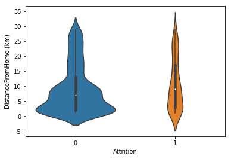

```python
sns.violinplot(x="Attrition", y="DistanceFromHome", data=IBM, scale='count');
plt.ylabel('DistanceFromHome (km)');
```

- Este gráfico nos mostra que há uma grande concentração de pessoas que moram entre 0 e 15 km do local de trabalho. E a proporção de pessoas que saem da empresa é maior nas pessoas que moram longe do trabalho.
- **Gráfico comparando Atrito na Empresa X Salário Mensal em U$ dos funcionários:**

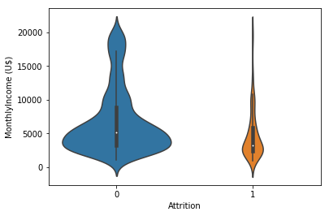

```python
sns.violinplot(x="Attrition", y="MonthlyIncome", data=IBM,scale="count");
plt.ylabel('MonthlyIncome (U$)');
```

- Este gráfico mostra que quanto maior o salário mensal por funcionário menor a chance de sair. Isso pode ser explicado pelo mesmo fator de um funcionário receber mais e por isso este não apresenta um atrito com a empresa.
- **Gráfico comparando Atrito na Empresa X Renda por hora em U$ dos funcionários:**

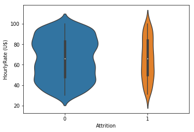

```python
sns.violinplot(x="Attrition", y="HourlyRate", data=IBM,scale='count');
plt.ylabel('HourlyRate (U$)');
```

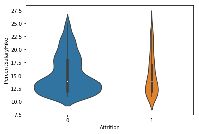

```python
sns.violinplot(x="Attrition", y="PercentSalaryHike", data=IBM, scale='count');
```

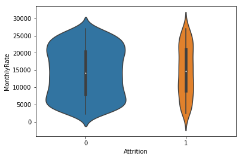

```python
sns.violinplot(x="Attrition", y="MonthlyRate", data=IBM, scale='count');
```

- Os gráficos são bem parecidos quando analisados pelo formato e por isso este dado não se apresenta tão relevante na análise.

**Satisfeitos com nossa análise, partimos para a elaboração dos modelos de machine learning.**

### Elaboração dos Modelos:

Para a elaboração, utilizamos 6 modelos diferentes (Random Forest, Gradient Boost, Regressão logística, SGD, Adaboost e SVM), com e sem SMOTE (Synthetic Minority Over-sampling Technique) nos modelos que o aceitavam.

```python
#Para utilizar esses metódos e outros, devemos trocar nossas  variaveis categoricas em dummys e separar o nosso teste(data)
#com o target, que será o que procuramos, ou seja: Attrition
quali = []

teste=IBM.drop(["Attrition"], axis=1)
teste.head()
```

|  | Age | BusinessTravel | Department | DistanceFromHome | Education | EducationField | EmployeeNumber | EnvironmentSatisfaction | Gender | HourlyRate | ... | PerformanceRating | RelationshipSatisfaction | StockOptionLevel | TotalWorkingYears | TrainingTimesLastYear | WorkLifeBalance | YearsAtCompany | YearsInCurrentRole | YearsSinceLastPromotion | YearsWithCurrManager |
| --- | --- | --- | --- | --- | --- | --- | --- | --- | --- | --- | --- | --- | --- | --- | --- | --- | --- | --- | --- | --- | --- |
| 0 | 41 | Travel_Rarely | Sales | 1 | 2 | Life Sciences | 1 | 2 | Female | 94 | ... | 3 | 1 | 0 | 8 | 0 | 1 | 6 | 4 | 0 | 5 |
| 1 | 49 | Travel_Frequently | Research & Development | 8 | 1 | Life Sciences | 2 | 3 | Male | 61 | ... | 4 | 4 | 1 | 10 | 3 | 3 | 10 | 7 | 1 | 7 |
| 2 | 37 | Travel_Rarely | Research & Development | 2 | 2 | Other | 4 | 4 | Male | 92 | ... | 3 | 2 | 0 | 7 | 3 | 3 | 0 | 0 | 0 | 0 |
| 3 | 33 | Travel_Frequently | Research & Development | 3 | 4 | Life Sciences | 5 | 4 | Female | 56 | ... | 3 | 3 | 0 | 8 | 3 | 3 | 8 | 7 | 3 | 0 |
| 4 | 27 | Travel_Rarely | Research & Development | 2 | 1 | Medical | 7 | 1 | Male | 40 | ... | 3 | 4 | 1 | 6 | 3 | 3 | 2 | 2 | 2 | 2 |

5 rows × 30 columns

```python
teste = pd.get_dummies(teste)
```

```python
target=IBM['Attrition']
```

```python
#Splita nosso teste e target em treino e teste, como pode-se notar, o train_size é o tamanho de sua amostra de treino, que
#deve ser maior do que sua teste, o recomendado é 66%, pelo livro hands-on machine learning with scikit-learn and tensorflow
#ou 75%
train, test, target_train, target_val = train_test_split(teste, target, train_size= 0.66,random_state=0);
```

[figure not shown]

- ### SMOTE (Synthetic Minority Over-sampling Technique):

  Como podemos notar, existe um desequilibrio entre as duas classes. Esse desequilibrio prejudicará nossas técnicas que serão utilizdas para ML, já que tais algoritmos tem dificuldade de aprender quando uma classe predomina a outra. Para resolver tal situação será utilizada o **SMOTE**.

  O SMOTE balanceia as variáveis da amostra, como vimos em nossa análise exploratória, a quantidade de pessoas que tem `NoAttrition` é muito superior em relação as que tem`Attrition`(84% X 16%), respecitvamente. Assim, essa amostra mostra-se desbalanceada, e por tal motivo, é necessário utilizar alguma técnica para balancear nossa amostra, por isso optamos pelo SMOTE (Oversampler).

  Esse balanceamento é feito, pegando a variável desbalanceada, no caso do nosso projeto é `Attrition`, o algoritmo então cria mais amostras com a classificação `Attrition`, mas ele altera os outros atributos por valores aleatórios dentro da diferença para os atributos vizinhos.

  Utilizando esse balanceamento, fizemos uma comparação dos resultados, em todos os modelos testados, menos no Gradient Boost, pois não é possível utilizar SMOTE nesse modelo. Assim, analisamos os dados de cada modelo observando os resultados com o SMOTE e sem o SMOTE, a fim de identificar a importância da utilização desse balanceamento entre `Attrition` e `NoAttrition`.

**Link com a Documentação do SMOTE:**

- [SMOTE:](https://medium.com/@saeedAR/smote-and-near-miss-in-python-machine-learning-in-imbalanced-datasets-b7976d9a7a79)
- Outra documentação explicando como o SMOTE funciona: [SMOTE](http://rikunert.com/SMOTE_explained)

```python
oversampler=SMOTE(random_state=0)
smote_train, smote_target = oversampler.fit_sample(train,target_train)
```

```python
bin1 = np.bincount(target_train)
bin2 = np.bincount(smote_target)
print('Amostra original=',bin1)
print('Amostra após utilizar o smote:',bin2)
#Pode-se ver que o SMOTE para balancear a quantidade de attriton e no attriton, criou novas "amostras" sinteticas
```

```
Amostra original= [813 157]
Amostra após utilizar o smote: [813 813]
```

- ## Random Forest

  O primeiro modelo escolhido pelo grupo foi o Random Forest o qual é um algoritmo de aprendizagem supervisionada que cria uma floresta de um modo aleatório, unindo diversas árvores de decisão, utilizando o metódo de bagging. Esse algoritmo é muito utilizado atualmente já que ele pode ser utilizado para tarefas de regressão e classificação.

**Link com a Documentação do RandomForest:**

- [RandomForest](https://towardsdatascience.com/understanding-random-forest-58381e0602d2)
- ### Random Forest (Sem SMOTE):

```python
seed = 0   # We set our random seed to zero for reproducibility
# Random Forest parameters
rf2_params = {
    'n_jobs': -1,
    'n_estimators': 1000,
    'warm_start': True,
    'max_features': 0.2,
    'max_depth': 6,
    'min_samples_leaf': 2,
    'max_features' : 'sqrt',
    'random_state' : seed,
    'verbose': 1
}
```

```python
rf = RandomForestClassifier(**rf2_params)
rf.fit(train,target_train)
rf_predictions = rf.predict(test)
accuracy_score(target_val,rf_predictions)

prediciton = pd.Series(rf_predictions)
pd.crosstab(prediciton,target_val, normalize='columns')
```

[output not shown]

| Attrition row_0 | 0 | 1 |
| --- | --- | --- |
| 0 | 0.971631 | 1.0 |
| 1 | 0.028369 | 0.0 |

- ### Random Forest (Sem SMOTE)

  Utilizando o modelo Random Forest, obtivemos os resultados abaixo:

**Obs: `NoAttrition` = 0 e `Attrition` = 1**

**Correspondência representada por Modelo X Dado Real:**

- **Não Correspondência 0 X 1: 2.83%**
- **Não Correspondência 1 X 0: 100%**
- **Correspondência 0 X 0 : 97.16%**
- **Correspondência 1 X 1: 0%**
- Ao utilizarmos o RandomForest optamos por plotar um gráfico que mostra a relevância de cada atributo, determinada pelo algoritmo do RandomForest, ele mostra as porcentagens de importância em cada um dos pontos do gráfico.

**Obs: Os dados não estão representados utilizando o SMOTE no algoritmo.**

```python
y = rf.feature_importances_
x=teste.columns.values
fig = px.scatter( x=x, y=y,color=y,
                  color_continuous_scale='Cividis')

fig.show()
```

[interactive chart not shown]

- ### Random Forest (Com SMOTE):

```python
rf2 = RandomForestClassifier(**rf2_params)
rf2.fit(smote_train, smote_target)
rf2_predictions = rf2.predict(test)

accuracy_score(target_val, rf2_predictions)
```

[output not shown]

```
0.868
```

**Plotamos também o gráfico de relevância para os dados com o SMOTE**

```python
y = rf2.feature_importances_
x=teste.columns.values
fig = px.scatter( x=x, y=y,color=y,
                  color_continuous_scale='Cividis')

fig.show()
```

[interactive chart not shown]

```python
prediction = pd.Series(rf2_predictions)
pd.crosstab(prediction,target_val,normalize='columns')
```

| Attrition row_0 | 0 | 1 |
| --- | --- | --- |
| 0 | 0.900709 | 0.913043 |
| 1 | 0.099291 | 0.086957 |

- ### Random Forest (Com SMOTE)

  Utilizando o modelo Random Forest, obtivemos os resultados abaixo:

**Obs: `NoAttrition` = 0 e `Attrition` = 1**

**Correspondência representada por Modelo X Dado Real:**

- **Não Correspondência 0 X 1: 9.92%**
- **Não Correspondência 1 X 0: 91.3%**
- **Correspondência 0 X 0 : 90%**
- **Correspondência 1 X 1: 8.69%**
- ### Gradient Boost:

  Outro modelo escolhido para criação do classificador foi o Gradient Boost, esse método converte modelos mais fracos em modelos mais fortes de aprendizado, ele primeiramente trina uma árvore de decisão em que todas as variáveis têm a mesma relevância.

  Após a primeira árvore, o algoritmo uma segunda árvore de decisão, e calcula a diferença entre o resultado da primeira árvore e do resultado real, assim o programa consegue prever as próximas diferenças dos resultados. Utilizando essas previsões, o Gradient Boost cria uma terceira árvore de decisão que une a Árvore 1 e a Árvore 2, portanto ele continua realizando essas iterações quantas vezes o usuário especificar.

  Por fim o algoritmo faz uma soma ponderada das previsões de todas as árvores, para então gerar os resultados do modelo.

**Link com a Documentação do Gradient Boost:**

- [Gradient Boost](https://towardsdatascience.com/machine-learning-part-18-boosting-algorithms-gradient-boosting-in-python-ef5ae6965be4)

```python
gradient = XGBClassifier()
gradient.fit(train, target_train)
```

```
XGBClassifier(base_score=0.5, booster='gbtree', colsample_bylevel=1,
              colsample_bynode=1, colsample_bytree=1, gamma=0,
              learning_rate=0.1, max_delta_step=0, max_depth=3,
              min_child_weight=1, missing=None, n_estimators=100, n_jobs=1,
              nthread=None, objective='binary:logistic', random_state=0,
              reg_alpha=0, reg_lambda=1, scale_pos_weight=1, seed=None,
              silent=None, subsample=1, verbosity=1)
```

```python
# make predictions for test data
y_pred = gradient.predict(test)
predictions = [round(value) for value in y_pred]

# evaluate predictions
accuracy = accuracy_score(y_pred, target_val)
print("Accuracy: %.2f%%" % (accuracy * 100.0))



pd.crosstab(y_pred,target_val,normalize='columns')
```

```
Accuracy: 87.60%
```

| Attrition row_0 | 0 | 1 |
| --- | --- | --- |
| 0 | 0.980952 | 0.675 |
| 1 | 0.019048 | 0.325 |

- ### Gradient Boost (Resultados):

  Utilizando o modelo Gradient Boost, obtivemos os resultados abaixo:

  **Obs: `NoAttrition` = 0 e `Attrition` = 1**

**Correspondência representada por Modelo X Dado Real:**

- **Não Correspondência 0 X 1: 1.9%**
- **Não Correspondência 1 X 0: 67.5%**
- **Correspondência 0 X 0: 98.09%**
- **Correspondência 1 X 1: 32.5%**
- **Nesse print abaixo, mostra-se o grau de importância que o Gradient Boost interpretou para cada atributo da Base de Dados que utilizamos:**

```python
gradient.get_booster().get_score(importance_type="gain")
```

```
{'OverTime_No': 8.04813549222222,
 'MonthlyIncome': 4.995825203450704,
 'JobRole_Research Scientist': 4.035905638333333,
 'MaritalStatus_Single': 6.589017867999999,
 'TotalWorkingYears': 5.0010261175,
 'HourlyRate': 3.1621396371428565,
 'WorkLifeBalance': 4.107986085625,
 'YearsAtCompany': 3.136542966666666,
 'JobInvolvement': 3.451937500421052,
 'StockOptionLevel': 6.280462625499999,
 'DistanceFromHome': 3.6126385329999997,
 'YearsWithCurrManager': 6.096704504642859,
 'EnvironmentSatisfaction': 3.842873687407407,
 'Age': 5.191997277475925,
 'BusinessTravel_Travel_Frequently': 4.926074028461539,
 'JobLevel': 8.273410414999999,
 'YearsInCurrentRole': 2.9172763424999997,
 'JobSatisfaction': 3.2480153457599994,
 'NumCompaniesWorked': 4.293732775625,
 'JobRole_Sales Executive': 6.709451544285715,
 'RelationshipSatisfaction': 3.5085460122800005,
 'EmployeeNumber': 3.062351009761905,
 'BusinessTravel_Non-Travel': 2.532826527142857,
 'PercentSalaryHike': 3.1428592046666664,
 'MonthlyRate': 2.7805755996388886,
 'YearsSinceLastPromotion': 3.366501533588235,
 'JobRole_Sales Representative': 3.6823115820000005,
 'EducationField_Technical Degree': 3.762796798333333,
 'JobRole_Laboratory Technician': 2.938800533333333,
 'JobRole_Manufacturing Director': 3.031598726666667,
 'Department_Research & Development': 4.023900127999999,
 'Education': 1.6746608,
 'EducationField_Marketing': 3.4663617650000003,
 'TrainingTimesLastYear': 2.354264775555555,
 'EducationField_Life Sciences': 1.5081555433333331,
 'Gender_Female': 2.52437536,
 'EducationField_Medical': 2.04899359,
 'Department_Sales': 1.86172229,
 'MaritalStatus_Married': 3.12836838,
 'EducationField_Human Resources': 1.46847081}
```

- ## Regressão Logística:

  Esse modelo se parece com uma regressão linear, porém os resultados são de variáveis binárias, no caso desse projeto “Attrition“ ou “NoAttrition”. A regressão linear é utilizada para encontrar relações entre dois atributos do DataFrame, para realizar essa tarefa, o algoritmo utiliza o MMQ (Método dos Mínimos Quadrados). Esse método, obtém uma reta que melhor correlaciona a relação entre os dados dos dois atributos em comparação, portanto o algoritmo realiza esse método múltiplas vezes entre todas as variáveis do DataFrame. Dessa forma, o programa cria um classificador baseados nesses cálculos.

```python
reg = linear_model.LogisticRegression()
```

```python
reg.fit(train, target_train)
y_pred = reg.predict(test)
```

```python
metrics.accuracy_score(target_val,y_pred)
```

```
0.88
```

```python
pd.crosstab(y_pred,target_val,normalize='columns')
```

| Attrition row_0 | 0 | 1 |
| --- | --- | --- |
| 0 | 0.990476 | 0.7 |
| 1 | 0.009524 | 0.3 |

- ### Regressão Logística (Sem SMOTE):

  Utilizando o modelo Regressão Logística, obtivemos os resultados abaixo:

  **Obs: `NoAttrition` = 0 e `Attrition` = 1**

**Correspondência representada por Modelo X Dado Real:**

- **Não Correspondência 0 X 1: 0.95%**
- **Não Correspondência 1 X 0: 70%**
- **Correspondência 0 X 0 : 99.04%**
- **Correspondência 1 X 1: 30%**
- ## Regressão Logística com SMOTE

```python
reg2 = linear_model.LogisticRegression()
reg2.fit(smote_train, smote_target)
y_pred2 = reg2.predict(test)
```

```python
metrics.accuracy_score(target_val,y_pred2)
```

```
0.86
```

```python
pd.crosstab(y_pred,target_val,normalize='columns')
```

| Attrition row_0 | 0 | 1 |
| --- | --- | --- |
| 0 | 0.990476 | 0.7 |
| 1 | 0.009524 | 0.3 |

- ### Regressão Logística (Com SMOTE):

- ### SGD (Stochastic Gradient Descent):

  O modelo SGD é um aperfeiçoamento do Gradient Descent (GD), o Stochastic Gradient Descent utiliza um ponto aleatório enquanto os pesos são alterados no treinamento, isso o torna mais eficiente, pois o modelo GD utiliza todos os dados do treinamento. Portanto, o SGD é mais rápido e consegue lidar com um dataset grande.

**Link da Documentação do SGD:**

- [SGD](https://towardsdatascience.com/how-to-make-sgd-classifier-perform-as-well-as-logistic-regression-using-parfit-cc10bca2d3c4)

```python
clf = SGDClassifier(loss="hinge", penalty="l2", max_iter=10000)
clf.fit(smote_train, smote_target)
y_pred5=clf.predict(test)
```

```python
pd.crosstab(y_pred5,target_val,normalize='columns')
```

| Attrition row_0 | 0 | 1 |
| --- | --- | --- |
| 0 | 0.502381 | 0.3875 |
| 1 | 0.497619 | 0.6125 |

- ### SGD:

  **Obs: `NoAttrition` = 0 e `Attrition` = 1**

  O modelo AdaBoost também une vários modelos considerados fracos gerando um classificador mais forte, assim como o Gradient Boost, porém o AdaBoost gera a segunda árvore com variáveis de pesos diferentes, de forma que as observações mais difíceis de serem classificadas têm seu peso aumentado, ao passo em que as variáveis de mais fácil observação têm seu peso reduzido.

  Dessa forma, o AdaBoost gera uma terceira árvore de decisão que une a Árvore 1 + Árvore 2 para melhorar as previsões da primeira árvore, assim o algoritmo itera por esse método o tanto de vezes especificadas como argumento da função do AdaBoost. Portanto, quando ele realiza todas as iterações possíveis, o programa realiza uma soma ponderada das previsões feitas pelas árvores, para então gerar os resultados do modelo.

**Link da Documentação do AdaBoost:**

- [AdaBoost](https://towardsdatascience.com/understanding-adaboost-2f94f22d5bfe)

```python
# Create adaboost classifer object
abc = AdaBoostClassifier(n_estimators=200,
                         learning_rate=1)
# Train Adaboost Classifer
classifier = abc.fit(train, target_train)

#Predict the response for test dataset
y_pred = classifier.predict(test)

print("Accuracy:",metrics.accuracy_score(target_val, y_pred))

pd.crosstab(y_pred,target_val,normalize='columns')
```

```
Accuracy: 0.844
```

| Attrition row_0 | 0 | 1 |
| --- | --- | --- |
| 0 | 0.935714 | 0.6375 |
| 1 | 0.064286 | 0.3625 |

- ### AdaBoost (Sem SMOTE)

  Utilizando o modelo AdaBoost, obtivemos os resultados abaixo:

**Obs: 0 = `NoAttrition` e 1 = `Attrition`**

**Correspondência representada por Modelo X Dado Real:**

```
* **Não Correspondência 0 X 1: 6.42%**
```

- **Não Correspondência 1 X 0: 63.75%**
- **Correspondência 0 X 0 : 93.57%**
- **Correspondência 1 X 1: 36.25%**

```python
# Create adaboost classifer object
abc = AdaBoostClassifier(n_estimators=200,
                         learning_rate=1)
# Train Adaboost Classifer
classifier = abc.fit(smote_train, smote_target)

#Predict the response for test dataset
y_pred = classifier.predict(test)

print("Accuracy:",metrics.accuracy_score(target_val, y_pred))

pd.crosstab(y_pred,target_val,normalize='columns')
```

```
Accuracy: 0.854
```

| Attrition row_0 | 0 | 1 |
| --- | --- | --- |
| 0 | 0.930952 | 0.55 |
| 1 | 0.069048 | 0.45 |

- ### AdaBoost (Com SMOTE)

  Utilizando o modelo AdaBoost, obtivemos os resultados abaixo:

**Obs: 0 = `NoAttrition` e 1 = `Attrition`**

**Correspondência representada por Modelo X Dado Real:**

```
* **Não Correspondência 0 X 1: 6.9%**
```

- **Não Correspondência 1 X 0: 55%**
- **Correspondência 0 X 0 : 93.09%**
- **Correspondência 1 X 1: 45%**
- ### SVM (Support Vector Machine):

  Esse algoritmo acha um hiperplano em n dimensões (n definido pelo número de atributos do modelo) e assim ele cria a classificação de acordo com as distinções dos dados. Os hiperplanos utilizados no SVM, são limites de decisão, eles ajudam a classificar os dados com mais precisão.

  O modelo SVM é muito utilizado atualmente, pois ele apresenta uma acurácia significativa e ele é menos pesado do que outros modelos para os computadores, esse algoritmo é muito utilizado para produção de classificadores, por isso optamos por ele como uma das alternativas do projeto.

**Link da Documentação do SVM:**

- [SVM](https://towardsdatascience.com/support-vector-machine-introduction-to-machine-learning-algorithms-934a444fca47)

```python
svclassifier = SVC(kernel='linear')
svclassifier.fit(train, target_train)
y_pred = svclassifier.predict(test)
```

```python
print(confusion_matrix(target_val,y_pred))
print(classification_report(target_val,y_pred))
```

```
[[409  11]
 [ 63  17]]
              precision    recall  f1-score   support

           0       0.87      0.97      0.92       420
           1       0.61      0.21      0.31        80

    accuracy                           0.85       500
   macro avg       0.74      0.59      0.62       500
weighted avg       0.83      0.85      0.82       500
```

```python
pd.crosstab(y_pred,target_val,normalize='columns')
```

| Attrition row_0 | 0 | 1 |
| --- | --- | --- |
| 0 | 0.97381 | 0.7875 |
| 1 | 0.02619 | 0.2125 |

- ### SVM (Sem SMOTE)

**Obs: `NoAttrition` = 0 e `Attrition` = 1**

**Correspondência representada por Modelo X Dado Real:**

- **Não Correspondência 0 X 1: 2.61%**
- **Não Correspondência 1 X 0: 78.75%**
- **Correspondência 0 X 0 : 97.38%**
- **Correspondência 1 X 1: 21.25%**

```python
svclassifier1 = SVC(kernel='sigmoid')
svclassifier1.fit(train, target_train)
y_pred1 = svclassifier1.predict(test)
```

```python
print(confusion_matrix(target_val,y_pred1))
print(classification_report(target_val,y_pred1))
```

```
[[420   0]
 [ 80   0]]
              precision    recall  f1-score   support

           0       0.84      1.00      0.91       420
           1       0.00      0.00      0.00        80

    accuracy                           0.84       500
   macro avg       0.42      0.50      0.46       500
weighted avg       0.71      0.84      0.77       500
```

```python
pd.crosstab(y_pred1,target_val,normalize='columns')
```

| Attrition row_0 | 0 | 1 |
| --- | --- | --- |
| 0 | 1 | 1 |

- ### SVM (Com SMOTE):

```python
svclassifier2 = SVC(kernel='linear')
svclassifier2.fit(smote_train, smote_target)
y_pred3 = svclassifier2.predict(test)
print(confusion_matrix(target_val,y_pred3))
print(classification_report(target_val,y_pred3))
```

[output not shown]

```python
pd.crosstab(y_pred3,target_val,normalize='columns')
```

[output not shown]

- ### SVM (Com SMOTE)

**Obs: `NoAttrition` = 0 e `Attrition` = 1**

## CONCLUSÃO:

### Hipóteses e Correlações:

Durante o desenvolvimento do projeto, a partir de diversos gráficos montados com algumas bibliotecas, ficaram claras correlações entre algumas variáveis com 'Atrition' e a falta de correlação com outras. Com esta análise inicial, foi possível também interpretar qual o impacto de cada variável. Para isso foram utilizados 'Scatterplots' e Histogramas plotados com Plotly e Seaborn, majoritariamente.

Para obter um escopo melhor e para não que não deixássemos de incluir análises importantes, experimentarmos com outros tipos de gráficos e diferentes jeitos de plotá-los. Foram usados gráficos de setores para melhor comparar porcentagens do nosso target em relação ao todo e outros tipos para análises mais específicas como o ‘Violin Plot’, que age como um boxplot mas com um gráfico de densidade de cada lado.

Satisfeitos com nossa análise, partimos para a elaboração dos modelos de machine learning.

### Elaboração dos Modelos:

Para a elaboração, utilizamos 6 modelos diferentes (Random Forest, Gradient Boost, Regressão logística, SGD, Adaboost e SVM), com e sem SMOTE (Synthetic Minority Over-sampling Technique) nos modelos que o aceitavam.